# Predicción de Zonas con Alta Contaminación por PM2.5

Práctica de Minería de Datos

Alicia Ruiz Simón

23/05/2025

[figure not shown]

# 0 Introducción

De acuerdo con [Murcia Salud](https://www.murciasalud.es/web/sanidad-ambiental/materia-particulada), la contaminación atmosférica por partículas en suspensión (PM) representa uno de los principales problemas de calidad del aire a nivel mundial, especialmente en entornos urbanos. Este tipo de contaminación está formado por una mezcla compleja de sólidos microscópicos y gotitas líquidas que se mantienen suspendidos en el aire, y que pueden tener un importante impacto en la salud humana.

En función de su tamaño, las partículas se clasifican principalmente en:

- PM10: partículas con un diámetro inferior a 10 micras. Proceden sobre todo de procesos mecánicos (polvo, construcción, resuspensión del suelo, tráfico).
- PM2.5: partículas con un diámetro inferior a 2,5 micras. Son las más peligrosas, ya que por su pequeño tamaño pueden penetrar profundamente en los pulmones y alcanzar el torrente sanguíneo. Su origen suele estar relacionado con procesos de combustión (tráfico, calefacción, industria, incendios). Estas partículas no solo afectan a la salud respiratoria y cardiovascular, sino que también tienen efectos sobre el medio ambiente (acidificación de suelos y aguas, afectación de cultivos, deterioro de edificios y monumentos) y pueden estar presentes durante todo el año, a diferencia de otros contaminantes como el ozono.

[figure not shown]

Tamaño de las partículas

En este trabajo, y siguiendo la clasificación empleada por distintas entidades de salud pública, se ha realizado un análisis de las concentraciones anuales de PM2.5 en Alemania entre 2003 y 2022, categorizando las zonas según sus niveles de contaminación en: Bajo, Moderado, Insalubre y Muy Insalubre, con el objetivo de predecir zonas con alta contaminación y su relación con otras variables que miden otras características de la calidad del aire.

## 0.1 Resumen Ejecutivo

A modo de resumen y aclaración de lo que se va a realizar en este proyecto, se redactan brevemente unos puntos sintetizando los pasos realizados y las conclusiones obtenidas en los distintos apartados.

### 0.1.1 Prepocesamiento de datos

En primer lugar, se realiza el preprocesamiento y análisis descriptivo de los datos. En primer lugar, se lleva a cabo la conversión de los tipos de datos para asegurar su correcta interpretación. A continuación, se identifican y gestionan los valores nulos mediante técnicas de imputación adecuadas calculando la media de los datos. Se detectan y tratan también los valores negativos, evaluando su validez o procediendo a su corrección o eliminación. Posteriormente, se eliminan columnas o filas que no aportan información relevante o que contienen datos inconsistentes como registros con los mismos datos.

#### 0.1.1.1 Análisis descriptivo

A continuación. se realiza un análisis descriptivo exhaustivo para obtener una visión general de las variables y su comportamiento o correlación. Durante este proceso, se respoonde a preguntas específicas para profundizar en la caracterización de las zonas según el nivel de contaminación por PM2.5.

Tras esto se elabora una tabla resumen con los principales resultados obtenidos. Finalmente, se guardan los datos preprocesados para su posterior uso y análisis.

#### 0.1.1.2 Técnicas de selección de variables

En esta etapa, se procede a la selección de variables comenzando con la división de los datos en conjuntos de entrenamiento y prueba. A continuación, se aplica un Análisis de Componentes Principales (PCA) con el fin de explorar la importancia relativa de las variables y entender su contribución en la variabilidad del conjunto de datos.

Sin embargo, para evitar la pérdida de interpretabilidad de variables como ocurre con el PCA, se emplea la técnica de Eliminación Recursiva de Variables (RFE), que permite seleccionar de manera más precisa las variables más importantes para el modelo. Estas variables son: `PM10_annualMean`, `bundesland`, `PM10_daysOver50`, `NO_annualMean`, `NO2_annualMean` y `O3_annualMean`. Cabe destacar que aunque la variable `year` habría sido seleccionada como variable relevante se eliminó en el preprocesamiento ya que no se considera una variable válida para las predicciones futuras y los resultados apenas varían sin esta variable.

### 0.1.2 Modelos predictivos

En esta sección, se inicia el entrenamiento de los modelos predictivos aplicando previamente un preprocesamiento riguroso que incluye la definición de la variable de control. Para abordar el desequilibrio en las clases, se utiliza la técnica SMOTE, la cual permite generar nuevas muestras sintéticas en la clase minoritaria, mejorando así la capacidad de aprendizaje de los modelos.

Se desarrollan tres modelos distintos para la predicción: primero, Random Forest (RF), un modelo basado en ensamblaje de árboles de decisión que proporciona robustez y buena capacidad de generalización; segundo, Support Vector Machine (SVM) con kernel radial, que permite capturar relaciones no lineales en los datos; y tercero, Gradient Boosting Machine (GBM), un método de ensamblaje que construye modelos secuenciales para optimizar el rendimiento.

Todos los modelos se entrenan y validan utilizando validación cruzada de cinco pliegues, garantizando una evaluación robusta y minimizando el riesgo de sobreajuste. Finalmente, se realiza una comparación de los modelos en base a sus métricas de desempeño, identificándose que Random Forest es el que presenta los mejores resultados en términos de precisión y estabilidad.

### 0.1.3 Aprendizaje profundo

Como último paso, se inicia el proceso de aprendizaje profundo con la carga de los datos correspondientes al conjunto de entrenamiento y prueba. En el preprocesamiento, se realiza un upsampling para equilibrar la distribución de clases, aumentando la cantidad de muestras en las clases minoritarias y evitando así el sesgo del modelo. Además, se aplica una normalización de las variables para asegurar una escala homogénea, facilitando el aprendizaje de la red neuronal. En esta ocasión, upsampling produce mejores resultados que SMOTE.

Posteriormente, los datos se convierten a matrices numéricas y las etiquetas se codifican mediante one-hot encoding, adaptándolas al formato requerido por el modelo. Se calcula el peso específico para cada clase, otorgando mayor importancia a las clases minoritarias durante el entrenamiento, lo que ayuda a mejorar la capacidad predictiva sobre estas categorías menos representadas.

La construcción del modelo se realiza definiendo una red neuronal con varias capas densas: una primera capa con 128 unidades y función de activación ReLU, seguida por capas con 64 y 32 unidades respectivamente, cada una acompañada de técnicas de dropout para reducir el sobreajuste. La capa final consta de 4 unidades con activación softmax, adaptada a un problema de clasificación multiclase.

El modelo se compila usando la función de pérdida `categorical_crossentropy` y el optimizador Adam con una tasa de aprendizaje de 0.0005, monitorizando la métrica de exactitud (accuracy). El entrenamiento se lleva a cabo utilizando los datos preprocesados y los pesos calculados para las clases, implementando técnicas que favorecen la generalización.

Finalmente, se evalúa el desempeño del modelo sobre el conjunto de prueba, analizando las métricas obtenidas para verificar su capacidad predictiva. Se generan las predicciones y se presentan los resultados para su interpretación y comparación con otros enfoques. Los resultados muestran una precisión global del 89.26%, indicando un buen desempeño general del modelo. La matriz de confusión revela que la mayoría de las muestras se clasifican correctamente, aunque existen confusiones entre las clases 1 y 2 que podrían mejorar. El modelo es robusto, aunque hay margen para mejorar la clasificación en clases con menor precisión.

### 0.1.4 Conclusiones del análisis realizado

En el último apartado se realiza una comparación detallada entre los cuatro modelos predictivos: SVM, Random Forest, GBM y la red neuronal, evaluando su desempeño mediante diversas métricas de clasificación. Para equilibrar el desbalance de clases, se utiliza SMOTE en los modelos tradicionales y upsampling en la red neuronal. Los resultados muestran que Random Forest es el modelo con mejor desempeño general, mientras que la red neuronal ofrece un buen balance entre precisión y sensibilidad, superando a GBM y SVM. SVM presenta el peor desempeño, posiblemente debido a su sensibilidad a la técnica de balanceo y a la complejidad del problema.

# 1 Preprocesamiento y análisis descriptivo de datos

Para iniciar el preprocesamiento y análisis descriptivo de los datos de calidad del aire, es fundamental cargar todas las librerías necesarias.

```r
# Librerías Generales
library(ggplot2)
library(knitr)
library(here)

# Librería Preprocesamiento
library(corrplot)

# Librerías Modelos Predictivos
library(caret)
library(pROC)
library(doParallel)
library(randomForest)
library(kableExtra)
library(dplyr)
library(themis)
library(tidyr)

# Librerías Aprendizaje Profundo
library(keras)
library(tensorflow)
library(recipes)
library(yardstick)
```

Con todas las librerías cargadas, se procede a especificar la ruta del proyecto y a realizar la importación e inspección inicial de los datos.

```r
# Especificar la ruta a emplear
ruta <- dirname(rstudioapi::getSourceEditorContext()$path)
```

Para poder realizar un preprocesamiento de los datos, primero es necesario visualizar los tipos de datos que se incluyen en el archivo.

```r
# Como los valores están separados por punto y coma se emplea `read.csv2`
datos <- read.csv2(file.path(ruta, "APExpose_DE__2003-2022__nogeo.csv"))

# Reemplazar los patrones problemáticos en la columna 'kreis'
datos$kreis <- gsub("Ã¼", "ü", datos$kreis)
datos$kreis <- gsub("Ã¤", "ä", datos$kreis)
datos$kreis <- gsub("Ã¶", "ö", datos$kreis)
datos$kreis <- gsub("Ã\u009f", "ß", datos$kreis)

# Guardar el archivo corregido
write.csv2(datos, file.path(ruta, "APExpose_DE__2003-2022__corregido.csv"), row.names = FALSE)

str(datos)
```

```
## 'data.frame':    24120 obs. of  15 variables:
##  $ kreis                : chr  "Freiburg im Breisgau" "Dillingen an der Donau" "Nürnberg" "Neumarkt in der Oberpfalz" ...
##  $ year                 : int  2019 2019 2019 2019 2019 2019 2019 2019 2019 2019 ...
##  $ NO2_annualMean       : chr  "16.01702" "13.4899217107555" "25.38003" "13.4007522894467" ...
##  $ NO2_hrOver200        : chr  "0" "0.00181758491765642" "0" "0.00169836295461625" ...
##  $ NO_annualMean        : chr  "8.020571" "9.44123735502931" "12.75646" "7.59858721547281" ...
##  $ O3_annualMean        : chr  "55.48591" "57.8306369760439" "45.58861" "57.1983119949486" ...
##  $ O3_daysOver120       : chr  "6" "3.94956030564142" "0" "3.69850462990315" ...
##  $ O3_dailyMaxAnnualMean: chr  "84.13068" "79.7920181719984" "73.69546" "79.4129100412683" ...
##  $ O3_dailyHourlyMax    : chr  "218.5" "175.735320848317" "160.3441" "175.684403073199" ...
##  $ O3_daily8HrMax       : chr  "206.925" "160.317081022046" "155.6718" "160.165432541125" ...
##  $ PM10_annualMean      : chr  "12.47323" "13.8484843229455" "17.6100515520758" "14.3041317974711" ...
##  $ PM10_daysOver50      : chr  "2" "1.7632754228681" "1.74017735699063" "1.74017735699063" ...
##  $ PM2.5_annualMean     : chr  "8.332781" "10.4951023570306" "11.51755" "10.4978516984895" ...
##  $ kreis_code           : int  12 68 107 110 122 240 241 281 291 312 ...
##  $ scenario             : chr  "remote" "remote" "remote" "remote" ...
```

Como se ha explicitado en la introducción de la práctica, se observa que hay 15 variables que definen distintos atributos relacionados con la medición de la calidad del aire. Además, tenemos 24120 observaciones. Cada observación incluye datos de la calidad del aire en una región alemana específica y un año determinado.

## 1.1 Conversión de tipos de datos

De las 15 variables que miden la calidad del aire, realmente solo once de ellas toman medidas de la calidad del aire, las demás sirven para especificar otro tipo de datos como la región `kreis`, el año `year`, el código de la zona `kreis_code` o la forma en la que se introdujeron los datos `scenario`. Los mencionados primeramente como los que miden el estado del aire están almacenados como tipo dato `character` pero deben ser de tipo `numeric`, por tanto, se realiza la conversión de estas once variables.

```r
# Seleccionamos todas las columnas que queremos convertir
variables_a_convertir <- c("NO2_annualMean", "NO2_hrOver200", "NO_annualMean", "O3_annualMean", "O3_daysOver120", "O3_dailyMaxAnnualMean", "O3_dailyHourlyMax", "O3_daily8HrMax", "PM10_annualMean", "PM10_daysOver50", "PM2.5_annualMean")

datos[variables_a_convertir] <- lapply(datos[variables_a_convertir], as.numeric)

# Pasamos `year`y `kreis_code` a tipo `char`
datos$year <- as.character(datos$year)
datos$kreis_code <- as.character(datos$kreis_code)
str(datos)
```

```
## 'data.frame':    24120 obs. of  15 variables:
##  $ kreis                : chr  "Freiburg im Breisgau" "Dillingen an der Donau" "Nürnberg" "Neumarkt in der Oberpfalz" ...
##  $ year                 : chr  "2019" "2019" "2019" "2019" ...
##  $ NO2_annualMean       : num  16 13.5 25.4 13.4 21 ...
##  $ NO2_hrOver200        : num  0 0.00182 0 0.0017 0.01182 ...
##  $ NO_annualMean        : num  8.02 9.44 12.76 7.6 13.95 ...
##  $ O3_annualMean        : num  55.5 57.8 45.6 57.2 50.1 ...
##  $ O3_daysOver120       : num  6 3.95 0 3.699 0.881 ...
##  $ O3_dailyMaxAnnualMean: num  84.1 79.8 73.7 79.4 75.2 ...
##  $ O3_dailyHourlyMax    : num  218 176 160 176 175 ...
##  $ O3_daily8HrMax       : num  207 160 156 160 158 ...
##  $ PM10_annualMean      : num  12.5 13.8 17.6 14.3 15.7 ...
##  $ PM10_daysOver50      : num  2 1.76 1.74 1.74 1.74 ...
##  $ PM2.5_annualMean     : num  8.33 10.5 11.52 10.5 11.5 ...
##  $ kreis_code           : chr  "12" "68" "107" "110" ...
##  $ scenario             : chr  "remote" "remote" "remote" "remote" ...
```

Además, como se va a realizar un análisis con los datos de la variable `PM2.3_annualMean` se debe discretizar en distintos valores según se especifica en la práctica. A mayor concentración de partículas PM2.5 peor será la calidad del aire.

```r
datos$PM2.5_categoria <- cut(datos$PM2.5_annualMean,
                             breaks = c(-Inf, 10, 25, 50, Inf),
                             labels = c("Bajo", "Moderado", "Insalubre", "Muy Insalubre"),
                             right = TRUE)
str(datos)
```

```
## 'data.frame':    24120 obs. of  16 variables:
##  $ kreis                : chr  "Freiburg im Breisgau" "Dillingen an der Donau" "Nürnberg" "Neumarkt in der Oberpfalz" ...
##  $ year                 : chr  "2019" "2019" "2019" "2019" ...
##  $ NO2_annualMean       : num  16 13.5 25.4 13.4 21 ...
##  $ NO2_hrOver200        : num  0 0.00182 0 0.0017 0.01182 ...
##  $ NO_annualMean        : num  8.02 9.44 12.76 7.6 13.95 ...
##  $ O3_annualMean        : num  55.5 57.8 45.6 57.2 50.1 ...
##  $ O3_daysOver120       : num  6 3.95 0 3.699 0.881 ...
##  $ O3_dailyMaxAnnualMean: num  84.1 79.8 73.7 79.4 75.2 ...
##  $ O3_dailyHourlyMax    : num  218 176 160 176 175 ...
##  $ O3_daily8HrMax       : num  207 160 156 160 158 ...
##  $ PM10_annualMean      : num  12.5 13.8 17.6 14.3 15.7 ...
##  $ PM10_daysOver50      : num  2 1.76 1.74 1.74 1.74 ...
##  $ PM2.5_annualMean     : num  8.33 10.5 11.52 10.5 11.5 ...
##  $ kreis_code           : chr  "12" "68" "107" "110" ...
##  $ scenario             : chr  "remote" "remote" "remote" "remote" ...
##  $ PM2.5_categoria      : Factor w/ 4 levels "Bajo","Moderado",..: 1 2 2 2 2 1 2 2 2 2 ...
```

## 1.2 Valores nulos e imputados

Una vez convertidos los tipos de datos, se analizan los nulos presente en los datos. Primero, se visualiza la cantidad de nulos que hay en cada variable.

```r
# Suma los nulos para cada columna
colSums(is.na(datos))
```

```
##                 kreis                  year        NO2_annualMean
##                     0                     0                    34
##         NO2_hrOver200         NO_annualMean         O3_annualMean
##                    34                    27                     9
##        O3_daysOver120 O3_dailyMaxAnnualMean     O3_dailyHourlyMax
##                    13                    13                    13
##        O3_daily8HrMax       PM10_annualMean       PM10_daysOver50
##                    13                    21                     9
##      PM2.5_annualMean            kreis_code              scenario
##                     3                     0                     0
##       PM2.5_categoria
##                     3
```

Se puede observar que no hay ninguna observación con todos sus valores nulos ya que hay atributos que no tienen ningún valor nulo. Analizando con mayor profundidad los registros con valores nulos, se especifica qué observaciones tienen datos nulos y cuántos son.

```r
# Contamos filas que al menos tengan un valor nulo
datos_con_nulos <- datos[apply(datos, 1, function(x) any(is.na(x))), ]  # Filtrar filas con al menos un NA
num_nulos_por_fila <- apply(datos_con_nulos, 1, function(x) sum(is.na(x)))  # Contar los NAs por fila

# Mostramos las filas con al menos un NA y el número de NAs en cada una
data.frame(Fila = rownames(datos_con_nulos), Nulos = num_nulos_por_fila)
```

```
##        Fila Nulos
## 318     318     4
## 720     720     4
## 1122   1122     4
## 1524   1524     2
## 1926   1926     2
## 2730   2730     1
## 3534   3534     1
## 3936   3936     9
## 4338   4338     9
## 4740   4740     4
## 6348   6348     4
## 6750   6750     4
## 7152   7152     4
## 7554   7554     7
```

[output cut: 32 more lines]

Tan solo 46 de las 24120 filas tienen valores nulos. Como cada fila tan solo tiene 15 datos, se decide eliminar aquellas con más de cuatro valores nulos ya que se puede considerar un número alto de nulos para tan pocas variables.

```r
# Aquellas filas con más de cuatro valores nulos serán eliminadas
datos_limpios <- datos[rowSums(is.na(datos)) <= 4, ]
```

En un principio, se pensó en imputar los valores faltantes calculando la media de la columna pero filtrando por `kreis_code` y `year`, es decir, calcular la media de la variable en un año y región específica, pero los resultados eran muy poco efectivos ya que tan solo se imputaban unos pocos datos. Por tanto, considerando la baja cantidad de nulos que hay en el dataset, se decide hacer la imputación directamente con las medias de cada variable.

```r
# Imputar los valores nulos con la media de cada columna
datos_imputados <- datos_limpios

# Para cada columna numérica, sustituimos los valores nulos por la media de esa columna
for (col in names(datos_imputados)) {
  if (is.numeric(datos_imputados[[col]])) {
    datos_imputados[[col]][is.na(datos_imputados[[col]])] <- mean(datos_imputados[[col]], na.rm = TRUE)
  }
}

# Recuento de valores nulos después de la imputación
colSums(is.na(datos_imputados))
```

```
##                 kreis                  year        NO2_annualMean
##                     0                     0                     0
##         NO2_hrOver200         NO_annualMean         O3_annualMean
##                     0                     0                     0
##        O3_daysOver120 O3_dailyMaxAnnualMean     O3_dailyHourlyMax
##                     0                     0                     0
##        O3_daily8HrMax       PM10_annualMean       PM10_daysOver50
##                     0                     0                     0
##      PM2.5_annualMean            kreis_code              scenario
##                     0                     0                     0
##       PM2.5_categoria
##                     3
```

Tras la imputación en las variables numéricas, se observa que en la variable `PM2.5_categoria` hay 3 valores nulos que no se han convertido al crear la variable factor a partir de `PM2.5_annualMean`.

```r
# Filtrar las filas que todavía tienen al menos un valor nulo
filas_con_nulos_restantes <- datos_imputados[rowSums(is.na(datos_imputados)) > 0, ]
filas_con_nulos_restantes
```

```
##                  kreis year NO2_annualMean NO2_hrOver200 NO_annualMean
## 14790 Osterode am Harz 2011       16.23630   0.005489566      5.922304
## 15192 Osterode am Harz 2011       16.48809   0.007105731      6.154209
## 15594 Osterode am Harz 2011       15.98777   0.006065271      5.793401
##       O3_annualMean O3_daysOver120 O3_dailyMaxAnnualMean O3_dailyHourlyMax
## 14790      49.89982      0.8007429              75.03713          175.0967
## 15192      49.43110      0.6984242              74.76834          174.9632
## 15594      49.95253      0.8306614              75.00224          174.9721
##       O3_daily8HrMax PM10_annualMean PM10_daysOver50 PM2.5_annualMean
## 14790       158.4151        18.92003        15.10488         12.24327
## 15192       158.2129        19.07238        15.40883         12.24327
## 15594       158.3463        18.87344        15.12840         12.24327
##       kreis_code scenario PM2.5_categoria
## 14790        229   remote            <NA>
## 15192        229  average            <NA>
## 15594        229    urban            <NA>
```

Por alaguna razón, en la creación de ese nuevo atributo como discretización de la variable `PM2.5_annualMean` no se han creado los datos. Por tanto, se introducen manualmente.

```r
# Imputamos los valores nulos restantes con "Moderado"
datos_imputados[is.na(datos_imputados)] <- "Moderado"

# Columnas con valores nulos
colSums(is.na(datos_imputados))
```

```
##                 kreis                  year        NO2_annualMean
##                     0                     0                     0
##         NO2_hrOver200         NO_annualMean         O3_annualMean
##                     0                     0                     0
##        O3_daysOver120 O3_dailyMaxAnnualMean     O3_dailyHourlyMax
##                     0                     0                     0
##        O3_daily8HrMax       PM10_annualMean       PM10_daysOver50
##                     0                     0                     0
##      PM2.5_annualMean            kreis_code              scenario
##                     0                     0                     0
##       PM2.5_categoria
##                     0
```

Además, se agrupan los distritos alemanes entre las distintas regiones llamadas `bundesland` para facilitar futuros análisis. Cada distrito `kreis` se incluye en una región `bundesland` para pasar de más de 400 distritos a tan solo 16 regiones.

```r
datos_imputados$bundesland <- NA

# Baden-Württemberg
datos_imputados$bundesland[datos_imputados$kreis %in% c("Alb-Donau-Kreis", "Baden-Baden", "Biberach", "Bodenseekreis", "Böblingen",
  "Breisgau-Hochschwarzwald", "Calw", "Emmendingen", "Enzkreis", "Esslingen", "Freudenstadt", "Freiburg im Breisgau",
  "Göppingen", "Heidelberg", "Heidenheim", "Heilbronn", "Hohenlohekreis", "Karlsruhe", "Konstanz", "Lörrach",
  "Ludwigsburg", "Main-Tauber-Kreis", "Mannheim", "Neckar-Odenwald-Kreis", "Ortenaukreis", "Ostalbkreis", "Pforzheim",
  "Rastatt", "Ravensburg", "Rems-Murr-Kreis", "Reutlingen", "Rhein-Neckar-Kreis", "Rottweil", "Schwäbisch Hall",
  "Schwarzwald-Baar-Kreis", "Sigmaringen", "Stuttgart", "Tübingen", "Tuttlingen", "Ulm", "Waldshut", "Zollernalbkreis")] <- "Baden-Württemberg"

# Bayern
datos_imputados$bundesland[datos_imputados$kreis %in% c("Aichach-Friedberg", "Altötting", "Amberg", "Amberg-Sulzbach", "Ansbach", "Aschaffenburg",
  "Augsburg", "Bad Kissingen", "Bad Tölz-Wolfratshausen", "Bamberg", "Bayreuth", "Berchtesgadener Land", "Cham",
  "Coburg", "Dachau", "Deggendorf", "Dillingen an der Donau", "Dingolfing-Landau", "Donau-Ries", "Ebersberg", "Eichstätt",
  "Erding", "Erlangen", "Erlangen-Höchstadt", "Forchheim", "Freising", "Freyung-Grafenau", "Fürstenfeldbruck",
  "Fürth", "Garmisch-Partenkirchen", "Günzburg", "Haßberge", "Hof", "Ingolstadt", "Kaufbeuren", "Kempten (Allgäu)", "Kelheim", "Kitzingen", "Kronach",
  "Kulmbach", "Landshut", "Landsberg am Lech", "Lichtenfels", "Lindau (Bodensee)", "Main-Spessart", "Memmingen",
  "Miesbach", "Miltenberg", "Mühldorf am Inn", "München", "Neuburg-Schrobenhausen", "Neumarkt in der Oberpfalz",
  "Neustadt an der Aisch-Bad Windsheim", "Neustadt an der Waldnaab", "Neu-Ulm", "Nürnberg", "Nürnberger Land", "Oberallgäu",
  "Ostallgäu", "Passau", "Pfaffenhofen an der Ilm", "Regen", "Regensburg", "Rhön-Grabfeld", "Rosenheim", "Roth", "Rottal-Inn", "Schwabach",
  "Schwandorf", "Schweinfurt", "Starnberg", "Straubing", "Straubing-Bogen", "Tirschenreuth", "Traunstein", "Unterallgäu", "Weiden in der Oberpfalz",
  "Weilheim-Schongau", "Weißenburg-Gunzenhausen", "Wunsiedel im Fichtelgebirge", "Würzburg")] <- "Bayern"

# Berlin
datos_imputados$bundesland[datos_imputados$kreis == "Berlin"] <- "Berlin"

# Brandenburg
datos_imputados$bundesland[datos_imputados$kreis %in% c("Barnim", "Brandenburg an der Havel", "Cottbus", "Dahme-Spreewald", "Elbe-Elster",
  "Frankfurt (Oder)", "Havelland", "Märkisch-Oderland", "Oberhavel", "Oberspreewald-Lausitz", "Oder-Spree", "Ostprignitz-Ruppin",
  "Potsdam", "Potsdam-Mittelmark", "Prignitz", "Spree-Neiße", "Teltow-Fläming", "Uckermark")] <- "Brandenburg"

# Bremen
datos_imputados$bundesland[datos_imputados$kreis %in% c("Bremen", "Bremerhaven")] <- "Bremen"

# Hamburg
datos_imputados$bundesland[datos_imputados$kreis == "Hamburg"] <- "Hamburg"

# Hessen
datos_imputados$bundesland[datos_imputados$kreis %in% c("Bergstraße", "Darmstadt", "Darmstadt-Dieburg", "Frankfurt am Main", "Fulda", "Gießen", "Groß-Gerau",
  "Hersfeld-Rotenburg", "Hochtaunuskreis", "Kassel", "Lahn-Dill-Kreis", "Limburg-Weilburg", "Main-Kinzig-Kreis",
  "Main-Taunus-Kreis", "Marburg-Biedenkopf", "Offenbach", "Offenbach am Main", "Odenwaldkreis", "Rheingau-Taunus-Kreis",
  "Schwalm-Eder-Kreis", "Vogelsbergkreis", "Waldeck-Frankenberg", "Werra-Meißner-Kreis", "Wetteraukreis",
  "Wiesbaden")] <- "Hessen"

# Mecklenburg-Vorpommern
datos_imputados$bundesland[datos_imputados$kreis %in% c("Mecklenburgische Seenplatte", "Rostock", "Vorpommern-Greifswald", "Nordwestmecklenburg",
  "Ludwigslust-Parchim", "Vorpommern-Rügen", "Schwerin")] <- "Mecklenburg-Vorpommern"

# Niedersachsen
datos_imputados$bundesland[datos_imputados$kreis %in% c("Ammerland", "Aurich", "Braunschweig", "Celle", "Cloppenburg", "Cuxhaven",
  "Delmenhorst", "Diepholz", "Emden", "Emsland", "Friesland", "Gifhorn", "Göttingen", "Goslar", "Grafschaft Bentheim", "Hameln-Pyrmont",
  "Harburg", "Heidekreis", "Helmstedt", "Hildesheim", "Holzminden", "Leer", "Lüchow-Dannenberg", "Lüneburg", "Nienburg (Weser)",
  "Northeim", "Oldenburg", "Oldenburg (Oldb)", "Osnabrück", "Osterholz", "Osterode am Harz", "Peine", "Region Hannover", "Rotenburg (Wümme)",
  "Salzgitter", "Schaumburg", "Stade", "Uelzen", "Vechta", "Verden", "Wesermarsch", "Wilhelmshaven", "Wittmund",
  "Wolfsburg", "Wolfenbüttel")] <- "Niedersachsen"

# Nordrhein-Westfalen
datos_imputados$bundesland[datos_imputados$kreis %in% c("Aachen", "Bielefeld", "Bochum", "Bonn", "Borken", "Bottrop", "Coesfeld", "Dortmund",
  "Duisburg", "Düren", "Düsseldorf", "Ennepe-Ruhr-Kreis", "Essen", "Euskirchen", "Gelsenkirchen", "Gütersloh", "Hagen", "Hamm",
  "Heinsberg", "Herford", "Herne", "Hochsauerlandkreis", "Höxter", "Kleve", "Köln", "Krefeld", "Leverkusen", "Lippe",
  "Märkischer Kreis", "Mettmann", "Minden-Lübbecke", "Mönchengladbach", "Mülheim an der Ruhr", "Münster", "Oberbergischer Kreis",
  "Oberhausen", "Olpe", "Paderborn", "Recklinghausen", "Remscheid", "Rhein-Erft-Kreis", "Rhein-Kreis Neuss", "Rhein-Sieg-Kreis",
  "Rheinisch-Bergischer Kreis", "Siegen-Wittgenstein", "Soest", "Solingen", "Städteregion Aachen", "Steinfurt", "Unna", "Viersen", "Warendorf",
  "Wesel", "Wuppertal")] <- "Nordrhein-Westfalen"

# Rheinland-Pfalz
datos_imputados$bundesland[datos_imputados$kreis %in% c("Ahrweiler", "Altenkirchen (Westerwald)", "Alzey-Worms", "Bad Dürkheim", "Bad Kreuznach",
  "Bernkastel-Wittlich", "Birkenfeld", "Bitburg-Prüm", "Cochem-Zell", "Donnersbergkreis", "Eifelkreis Bitburg-Prüm",
  "Frankenthal", "Frankenthal (Pfalz)", "Germersheim", "Kaiserslautern", "Koblenz", "Kusel", "Landau in der Pfalz", "Ludwigshafen am Rhein", "Mainz", "Mainz-Bingen", "Mayen-Koblenz", "Neustadt an der Weinstraße",
  "Neuwied", "Pirmasens", "Rhein-Hunsrück-Kreis", "Rhein-Lahn-Kreis", "Rhein-Pfalz-Kreis", "Speyer", "Südliche Weinstraße",
  "Südwestpfalz", "Trier", "Trier-Saarburg", "Vulkaneifel", "Westerwaldkreis", "Worms", "Zweibrücken")] <- "Rheinland-Pfalz"

# Saarland
datos_imputados$bundesland[datos_imputados$kreis %in% c("Merzig-Wadern", "Neunkirchen", "Regionalverband Saarbrücken", "Saarlouis",
  "Saarpfalz-Kreis", "St. Wendel")] <- "Saarland"

# Sachsen
datos_imputados$bundesland[datos_imputados$kreis %in% c("Bautzen", "Dresden", "Leipzig", "Chemnitz", "Sächsische Schweiz-Osterzgebirge", "Vogtlandkreis",
  "Mittelsachsen", "Zschopau", "Nordsachsen", "Landkreis Meißen", "Landkreis Leipzig", "Landkreis Zwickau", "Zwickau", "Sachsen-Anhalt", "Erzgebirgskreis", "Görlitz", "Meißen")] <- "Sachsen"

# Sachsen-Anhalt
datos_imputados$bundesland[datos_imputados$kreis %in% c("Altmarkkreis Salzwedel", "Anhalt-Bitterfeld", "Börde", "Burgenlandkreis",
  "Dessau-Roßlau", "Halle (Saale)", "Harz", "Jerichower Land", "Magdeburg", "Mansfeld-Südharz", "Saalekreis",
  "Salzlandkreis", "Stendal", "Wittenberg")] <- "Sachsen-Anhalt"

# Schleswig-Holstein
datos_imputados$bundesland[datos_imputados$kreis %in% c("Dithmarschen", "Flensburg", "Herzogtum Lauenburg", "Kiel", "Lübeck", "Neumünster",
  "Nordfriesland", "Ostholstein", "Pinneberg", "Plön", "Rendsburg-Eckernförde", "Schleswig-Flensburg", "Segeberg",
  "Steinburg", "Stormarn")] <- "Schleswig-Holstein"

# Thüringen
datos_imputados$bundesland[datos_imputados$kreis %in% c("Altenburger Land", "Eichsfeld", "Eisenach", "Erfurt", "Gera", "Gotha", "Greiz", "Hildburghausen",
  "Ilm-Kreis", "Jena", "Kyffhäuserkreis", "Nordhausen", "Saale-Holzland-Kreis", "Saale-Orla-Kreis", "Saalekreis",
  "Schmalkalden-Meiningen", "Saalfeld-Rudolstadt", "Sömmerda", "Sonneberg", "Suhl", "Unstrut-Hainich-Kreis", "Weimar", "Weimarer Land",
  "Wartburgkreis")] <- "Thüringen"


colSums(is.na(datos_imputados))
```

```
##                 kreis                  year        NO2_annualMean
##                     0                     0                     0
##         NO2_hrOver200         NO_annualMean         O3_annualMean
##                     0                     0                     0
##        O3_daysOver120 O3_dailyMaxAnnualMean     O3_dailyHourlyMax
##                     0                     0                     0
##        O3_daily8HrMax       PM10_annualMean       PM10_daysOver50
##                     0                     0                     0
##      PM2.5_annualMean            kreis_code              scenario
##                     0                     0                     0
##       PM2.5_categoria            bundesland
##                     0                     0
```

```r
head(datos_imputados)
```

```
##                       kreis year NO2_annualMean NO2_hrOver200 NO_annualMean
## 1      Freiburg im Breisgau 2019       16.01702   0.000000000      8.020571
## 2    Dillingen an der Donau 2019       13.48992   0.001817585      9.441237
## 3                  Nürnberg 2019       25.38003   0.000000000     12.756460
## 4 Neumarkt in der Oberpfalz 2019       13.40075   0.001698363      7.598587
## 5                 Rosenheim 2019       20.96812   0.011816137     13.947993
## 6             Wilhelmshaven 2019       10.79080   0.000000000      5.827101
##   O3_annualMean O3_daysOver120 O3_dailyMaxAnnualMean O3_dailyHourlyMax
## 1      55.48591      6.0000000              84.13068          218.5000
## 2      57.83064      3.9495603              79.79202          175.7353
## 3      45.58861      0.0000000              73.69546          160.3441
## 4      57.19831      3.6985046              79.41291          175.6844
## 5      50.10122      0.8807067              75.15788          175.1129
## 6      54.85508      0.0000000              74.48273          184.0290
##   O3_daily8HrMax PM10_annualMean PM10_daysOver50 PM2.5_annualMean kreis_code
## 1       206.9250        12.47323        2.000000         8.332781         12
## 2       160.3171        13.84848        1.763275        10.495102         68
## 3       155.6718        17.61005        1.740177        11.517550        107
## 4       160.1654        14.30413        1.740177        10.497852        110
## 5       158.4634        15.70417        1.740177        11.495740        122
## 6       161.8678        14.68957        1.000000         9.892700        240
##   scenario PM2.5_categoria        bundesland
## 1   remote            Bajo Baden-Württemberg
## 2   remote        Moderado            Bayern
## 3   remote        Moderado            Bayern
## 4   remote        Moderado            Bayern
## 5   remote        Moderado            Bayern
## 6   remote            Bajo     Niedersachsen
```

## 1.3 Valores negativos

Se prodece a realizar un análisis de valores negativos para las variables numéricas.

```r
# Filtrar solo las columnas numéricas
datos_num <- datos_imputados[, sapply(datos_imputados, is.numeric)]

# Análisis descriptivo básico para las columnas numéricas
summary(datos_num)
```

```
##  NO2_annualMean    NO2_hrOver200      NO_annualMean    O3_annualMean
##  Min.   : 0.2302   Min.   :0.000000   Min.   :-3.067   Min.   :11.32
##  1st Qu.:13.0127   1st Qu.:0.000000   1st Qu.: 4.681   1st Qu.:47.42
##  Median :16.4315   Median :0.000000   Median : 7.255   Median :50.85
##  Mean   :17.2028   Mean   :0.007640   Mean   : 8.620   Mean   :51.02
##  3rd Qu.:20.5030   3rd Qu.:0.007135   3rd Qu.:10.886   3rd Qu.:54.34
##  Max.   :45.4021   Max.   :3.000000   Max.   :62.096   Max.   :96.72
##  O3_daysOver120   O3_dailyMaxAnnualMean O3_dailyHourlyMax O3_daily8HrMax
##  Min.   : 0.000   Min.   : 53.93        Min.   : 76.08    Min.   : 71.91
##  1st Qu.: 0.000   1st Qu.: 74.07        1st Qu.:174.73    1st Qu.:157.66
##  Median : 1.000   Median : 75.62        Median :175.10    Median :158.58
##  Mean   : 1.483   Mean   : 75.68        Mean   :175.11    Mean   :158.62
##  3rd Qu.: 2.000   3rd Qu.: 77.45        3rd Qu.:175.43    3rd Qu.:159.44
##  Max.   :45.000   Max.   :107.28        Max.   :313.60    Max.   :249.51
##  PM10_annualMean PM10_daysOver50   PM2.5_annualMean
##  Min.   : 3.86   Min.   :-0.6219   Min.   :-59.26
##  1st Qu.:15.42   1st Qu.: 2.0000   1st Qu.: 10.91
##  Median :17.73   Median : 6.0000   Median : 12.61
##  Mean   :17.92   Mean   : 7.6033   Mean   : 12.24
##  3rd Qu.:20.13   3rd Qu.:10.8309   3rd Qu.: 13.83
##  Max.   :37.08   Max.   :78.0000   Max.   :147.02
```

Se puede comprobar que hay variables con valores negativos y eso no puede ser posible, primero observamos cuántos valores negativos aparecen.

```r
# Encontrar las variables con valores negativos y contar cuántos valores negativos hay en cada una
valores_negativos <- sapply(datos_imputados[, sapply(datos_imputados, is.numeric)], function(x) sum(x < 0, na.rm = TRUE))

# Filtrar las variables que tienen valores negativos
valores_negativos <- valores_negativos[valores_negativos > 0]

# Mostrar las variables con valores negativos y el conteo de los valores negativos
valores_negativos
```

```
##    NO_annualMean  PM10_daysOver50 PM2.5_annualMean
##               22                3              541
```

Como se dispone de una cantidad de observaciones elevada, se puede prescindir de estos registros que contienen valores negativos.

```r
# Eliminar filas donde la columna PM2.5_annualMean tiene valores negativos
datos_imputados <- datos_imputados[datos_imputados$PM2.5_annualMean >= 0, ]

# Eliminar filas donde la columna NO_annualMean tiene valores negativos
datos_imputados <- datos_imputados[datos_imputados$NO_annualMean >= 0, ]

# Eliminar filas donde la columna PM10_daysOver50 tiene valores negativos
datos_imputados <- datos_imputados[datos_imputados$PM10_daysOver50 >= 0, ]
summary(datos_imputados)
```

```
##     kreis               year           NO2_annualMean    NO2_hrOver200
##  Length:23544       Length:23544       Min.   : 0.2302   Min.   :0.000000
##  Class :character   Class :character   1st Qu.:12.9461   1st Qu.:0.000000
##  Mode  :character   Mode  :character   Median :16.3771   Median :0.000000
##                                        Mean   :17.1483   Mean   :0.007612
##                                        3rd Qu.:20.3996   3rd Qu.:0.007011
##                                        Max.   :45.4021   Max.   :3.000000
##  NO_annualMean      O3_annualMean   O3_daysOver120   O3_dailyMaxAnnualMean
##  Min.   : 0.00432   Min.   :11.32   Min.   : 0.000   Min.   : 53.93
##  1st Qu.: 4.68657   1st Qu.:47.35   1st Qu.: 0.000   1st Qu.: 74.02
##  Median : 7.24191   Median :50.81   Median : 1.000   Median : 75.59
##  Mean   : 8.64736   Mean   :50.95   Mean   : 1.463   Mean   : 75.64
##  3rd Qu.:10.93019   3rd Qu.:54.27   3rd Qu.: 2.000   3rd Qu.: 77.40
##  Max.   :62.09627   Max.   :96.72   Max.   :45.000   Max.   :107.28
##  O3_dailyHourlyMax O3_daily8HrMax   PM10_annualMean PM10_daysOver50
##  Min.   : 76.08    Min.   : 71.91   Min.   : 3.86   Min.   : 0.000
##  1st Qu.:174.71    1st Qu.:157.61   1st Qu.:15.35   1st Qu.: 2.000
##  Median :175.10    Median :158.57   Median :17.66   Median : 5.919
##  Mean   :175.09    Mean   :158.60   Mean   :17.78   Mean   : 7.274
##  3rd Qu.:175.42    3rd Qu.:159.42   3rd Qu.:19.92   3rd Qu.:10.434
##  Max.   :313.60    Max.   :249.51   Max.   :37.08   Max.   :78.000
##  PM2.5_annualMean  kreis_code          scenario              PM2.5_categoria
##  Min.   :  0.00   Length:23544       Length:23544       Bajo         : 3980
##  1st Qu.: 11.28   Class :character   Class :character   Moderado     :19312
##  Median : 12.65   Mode  :character   Mode  :character   Insalubre    :  174
##  Mean   : 12.83                                         Muy Insalubre:   78
##  3rd Qu.: 13.86
##  Max.   :147.02
##   bundesland
##  Length:23544
##  Class :character
##  Mode  :character
##
##
##
```

## 1.4 Eliminación de columnas o filas

Tras un breve análisis superficial de los datos y del objetivo del proyecto, se consdiera que las variables `kreis`, `kreis_code` y `scenario` no son necesarias. Por un lado, ni `kreis` ni `kreis_code` son necesarias ya que se han agrupado las observaciones por región siendo prescindible la especificación del distrito en concreto. Por otro lado, la variable `scenario` que describe cómo se han introducido los datos no es importante para este análisis. Además, la variable `year` no se considera necesaria para futuros análisis y no debe considerarse para predicción de calidad del aire.

```r
# Eliminamos las variables `kreis` y `scenario`
datos_imputados <- datos_imputados[, !(colnames(datos_imputados) %in% c("kreis", "scenario", "year", "kreis_code"))]
dim(datos_imputados)
```

```
## [1] 23544    13
```

En cuanto a la variable `PM2.5_annualMean` se deberá eliminar para predicciones pero se deja en el conjunto de datos por el momento para analizar su relación con otras variables numéricas.

```r
# Eliminar columnas que no tienen variabilidad (si todos los valores son iguales)
datos_imputados <- datos_imputados[, sapply(datos_imputados, function(x) length(unique(x)) > 1)]
dim(datos_imputados)
```

```
## [1] 23544    13
```

## 1.5 Análisis descriptivo

A continuación, se analiza la correlación entre las variables.

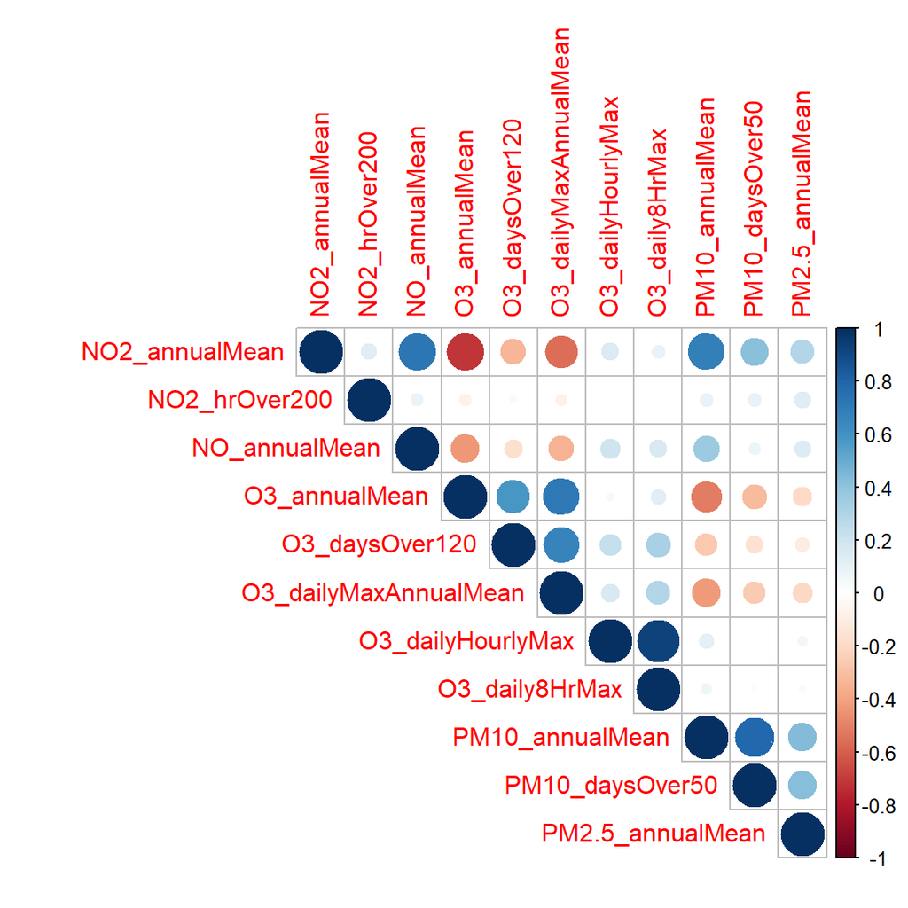

```r
# Ver correlaciones entre las variables numéricas
correlaciones <- cor(datos_imputados[, sapply(datos_imputados, is.numeric)], use = "complete.obs")

# Visualizamos la matriz de correlación
corrplot(correlaciones, type= "upper", method = "circle")
```

```r
# Correlaciones con PM2.5_annualMean
correlaciones_PM25_annualMean <- correlaciones["PM2.5_annualMean", ]

# Mostrar las correlaciones
correlaciones_PM25_annualMean
```

```
##        NO2_annualMean         NO2_hrOver200         NO_annualMean
##            0.29230780            0.13975488            0.14086140
##         O3_annualMean        O3_daysOver120 O3_dailyMaxAnnualMean
##           -0.19157444           -0.10593472           -0.20216185
##     O3_dailyHourlyMax        O3_daily8HrMax       PM10_annualMean
##            0.05343943            0.02988507            0.43431825
##       PM10_daysOver50      PM2.5_annualMean
##            0.42421484            1.00000000
```

Aunque la matriz de correlación no muestra relaciones lineales fuertes entre `PM2.5_annualMean` y el resto de variables, esto no implica que no puedan ser útiles para un modelo de clasificación, ya que estos pueden capturar relaciones no lineales o combinaciones complejas de variables. En el siguiente apartado del trabajo se evaluará su relevancia con técnicas como selección de variables y PCA. Aún así podemos observar que variables como `PM10_annualMean` O `PM10_daysOver50`mantienen algo de correlación con `PM2.5_annualMean`.

Es posible mostrar cómo se clasifican las observaciones según su contaminación.

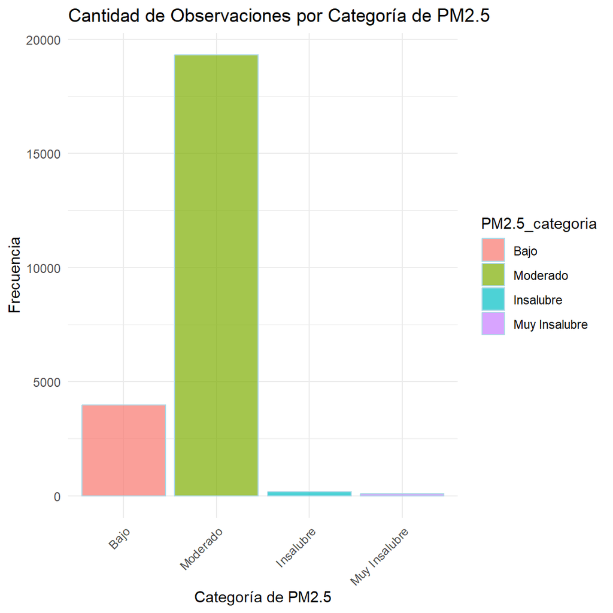

```r
# Creamos un histograma para la variable PM2.5_categoria
ggplot(datos_imputados, aes(x = PM2.5_categoria, fill = PM2.5_categoria)) +
  geom_bar(color = "lightblue", alpha = 0.7) +
  labs(title = "Cantidad de Observaciones por Categoría de PM2.5",
       x = "Categoría de PM2.5",
       y = "Frecuencia") +
  theme_minimal() +
  theme(axis.text.x = element_text(angle = 45, hjust = 1))
```

El gráfico anterior muestra la distribución de observaciones según la categoría de concentración de PM2.5. Se observa un fuerte desbalance de clases, donde la categoría “Moderado” agrupa la mayoría de los registros, con una frecuencia muy superior al resto. En contraste, la categoría “Muy Insalubre” presenta la menor cantidad de observaciones, seguida de “Insalubre”.

Este desbalance es importante tenerlo en cuenta, ya que puede afectar el rendimiento de los modelos predictivos, especialmente en métricas como la precisión por clase o la capacidad del modelo para identificar correctamente las clases minoritarias. Por tanto, en las siguientes etapas del análisis se considerará aplicar técnicas de balanceo como SMOTE o upsampling para mitigar este problema.

## 1.6 Preguntas 1 y 2

En esta sección se prosigue con el análisis descriptivo y la respuesta a las preguntas planteadas.

```r
# Filtrar las zonas con según contaminación
alta_contaminacion <- datos_imputados[datos_imputados$PM2.5_categoria == "Muy Insalubre", ]
baja_contaminacion <- datos_imputados[datos_imputados$PM2.5_categoria == "Bajo", ]

# Resumen de las estadísticas descriptivas para las zonas de alta contaminación
print("Alta contaminación:")
```

```
## [1] "Alta contaminación:"
```

```r
       summary(alta_contaminacion)
```

```
##  NO2_annualMean   NO2_hrOver200     NO_annualMean    O3_annualMean
##  Min.   : 9.769   Min.   :0.00000   Min.   : 1.265   Min.   :34.20
##  1st Qu.:20.016   1st Qu.:0.00000   1st Qu.: 6.354   1st Qu.:39.93
##  Median :34.929   Median :0.00000   Median :19.306   Median :43.51
##  Mean   :29.874   Mean   :0.19852   Mean   :16.879   Mean   :46.06
##  3rd Qu.:38.203   3rd Qu.:0.03972   3rd Qu.:23.965   3rd Qu.:50.86
##  Max.   :43.992   Max.   :2.00000   Max.   :37.486   Max.   :68.76
##  O3_daysOver120  O3_dailyMaxAnnualMean O3_dailyHourlyMax O3_daily8HrMax
##  Min.   :0.000   Min.   :65.82         Min.   :173.5     Min.   :154.5
##  1st Qu.:0.000   1st Qu.:70.24         1st Qu.:174.3     1st Qu.:156.3
##  Median :0.000   Median :72.19         Median :174.6     Median :157.2
##  Mean   :1.162   Mean   :73.63         Mean   :174.8     Mean   :157.8
##  3rd Qu.:3.204   3rd Qu.:79.12         3rd Qu.:175.7     3rd Qu.:160.1
##  Max.   :4.581   Max.   :80.75         Max.   :175.9     Max.   :160.7
##  PM10_annualMean PM10_daysOver50 PM2.5_annualMean      PM2.5_categoria
##  Min.   :19.85   Min.   : 0.00   Min.   : 53.99   Bajo         : 0
##  1st Qu.:25.30   1st Qu.:21.41   1st Qu.: 60.24   Moderado     : 0
##  Median :27.89   Median :29.09   Median : 67.50   Insalubre    : 0
##  Mean   :27.33   Mean   :27.95   Mean   : 73.21   Muy Insalubre:78
##  3rd Qu.:29.01   3rd Qu.:31.00   3rd Qu.: 78.02
##  Max.   :34.68   Max.   :61.00   Max.   :147.02
##   bundesland
##  Length:78
##  Class :character
##  Mode  :character
##
##
##
```

```r
# Resumen de las estadísticas descriptivas para las zonas de baja contaminación
print("Baja contaminación:")
```

```
## [1] "Baja contaminación:"
```

```r
summary(baja_contaminacion)
```

```
##  NO2_annualMean    NO2_hrOver200      NO_annualMean      O3_annualMean
##  Min.   : 0.2302   Min.   :0.000000   Min.   : 0.07653   Min.   :27.79
##  1st Qu.: 9.4369   1st Qu.:0.000000   1st Qu.: 2.98753   1st Qu.:51.20
##  Median :11.7170   Median :0.000000   Median : 5.50782   Median :54.54
##  Mean   :12.5170   Mean   :0.002849   Mean   : 6.19836   Mean   :54.86
##  3rd Qu.:14.9173   3rd Qu.:0.000000   3rd Qu.: 8.02057   3rd Qu.:56.89
##  Max.   :43.5069   Max.   :1.000000   Max.   :37.38363   Max.   :96.72
##  O3_daysOver120   O3_dailyMaxAnnualMean O3_dailyHourlyMax O3_daily8HrMax
##  Min.   : 0.000   Min.   : 61.89        Min.   :131.4     Min.   :118.5
##  1st Qu.: 0.000   1st Qu.: 75.81        1st Qu.:169.0     1st Qu.:153.5
##  Median : 1.866   Median : 77.64        Median :175.3     Median :159.1
##  Mean   : 2.218   Mean   : 77.71        Mean   :171.8     Mean   :156.5
##  3rd Qu.: 3.000   3rd Qu.: 79.14        3rd Qu.:175.6     3rd Qu.:159.9
##  Max.   :43.500   Max.   :107.28        Max.   :243.8     Max.   :214.0
##  PM10_annualMean PM10_daysOver50   PM2.5_annualMean      PM2.5_categoria
##  Min.   : 3.86   Min.   : 0.0000   Min.   : 0.000   Bajo         :3980
##  1st Qu.:12.64   1st Qu.: 0.6646   1st Qu.: 8.621   Moderado     :   0
##  Median :13.25   Median : 1.0000   Median : 9.024   Insalubre    :   0
##  Mean   :14.16   Mean   : 2.6858   Mean   : 8.604   Muy Insalubre:   0
##  3rd Qu.:14.69   3rd Qu.: 1.9659   3rd Qu.: 9.282
##  Max.   :32.27   Max.   :55.0000   Max.   :10.000
##   bundesland
##  Length:3980
##  Class :character
##  Mode  :character
##
##
##
```

```r
# Calcular la media de las variables para zonas de alta contaminación
media_alta <- colMeans(alta_contaminacion[, sapply(alta_contaminacion, is.numeric)], na.rm = TRUE)

# Calcular la media de las variables para zonas de baja contaminación
media_baja <- colMeans(baja_contaminacion[, sapply(baja_contaminacion, is.numeric)], na.rm = TRUE)

# Crear un dataframe con las medias de las dos categorías
medias <- data.frame(
  variable = names(media_alta),
  Muy_Insalubre = media_alta,
  Bajo = media_baja
)

# Ver el dataframe
head(medias)
```

```
##                                    variable Muy_Insalubre         Bajo
## NO2_annualMean               NO2_annualMean    29.8738896 12.517015633
## NO2_hrOver200                 NO2_hrOver200     0.1985242  0.002848742
## NO_annualMean                 NO_annualMean    16.8791592  6.198361138
## O3_annualMean                 O3_annualMean    46.0596577 54.855559540
## O3_daysOver120               O3_daysOver120     1.1622318  2.218114660
## O3_dailyMaxAnnualMean O3_dailyMaxAnnualMean    73.6339562 77.714767890
```

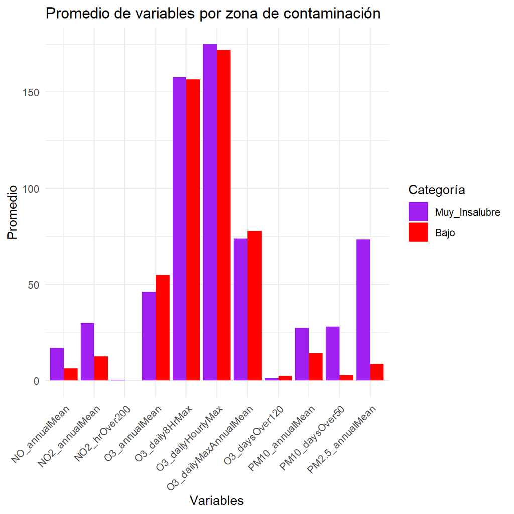

```r
# Transformar el dataframe para usarlo en ggplot
medias_long <- reshape2::melt(medias, id.vars = "variable", variable.name = "categoria", value.name = "media")

# Graficar
ggplot(medias_long, aes(x = variable, y = media, fill = categoria)) +
  geom_bar(stat = "identity", position = "dodge") +
  scale_fill_manual(values = c("Muy_Insalubre" = "purple", "Bajo" = "red")) +
  theme_minimal() +
  labs(title = "Promedio de variables por zona de contaminación",
       x = "Variables", y = "Promedio", fill = "Categoría") +
  theme(axis.text.x = element_text(angle = 45, hjust = 1))
```

**Pregunta 1 | ¿Cuáles son las características de las zonas con alta contaminación por PM2.5?** **Pregunta 2 | ¿Cuáles son las características de las zonas con baja contaminación por PM2.5?**

En base a las métricas y gráficas anteriormente realizadas, se pueden obtener las siguientes conclusiones:

### 1.6.1 Caracterización de las zonas según el nivel de contaminación por PM2.5

A partir de la discretización de la variable `PM2.5_annualMean`, se han definido cuatro niveles de contaminación: **Bajo**, **Moderada**, **Insalubre** y **Muy Insalubre**. A continuación, se resumen las características más representativas de las zonas en cada uno de estos niveles: